# R-Funktionen

# R-Funktionen

Diese Seite listet all die R-Funktionen auf die ich schonmal benutzt habe. Ich versuche so weit es geht die ausgeführten Beispiele mit anzuzeigen. ***

Mit ? können wird die Dokumentation von R aufgerufen und weitere zusätzliche Informationen werden angezeigt.

```r
# zum Beispiel
?row.names
```

[output not shown]

```r
# zeigt alle Observations an
row.names(mtcars)
```

```
##  [1] "Mazda RX4"           "Mazda RX4 Wag"       "Datsun 710"
##  [4] "Hornet 4 Drive"      "Hornet Sportabout"   "Valiant"
##  [7] "Duster 360"          "Merc 240D"           "Merc 230"
## [10] "Merc 280"            "Merc 280C"           "Merc 450SE"
## [13] "Merc 450SL"          "Merc 450SLC"         "Cadillac Fleetwood"
## [16] "Lincoln Continental" "Chrysler Imperial"   "Fiat 128"
## [19] "Honda Civic"         "Toyota Corolla"      "Toyota Corona"
## [22] "Dodge Challenger"    "AMC Javelin"         "Camaro Z28"
## [25] "Pontiac Firebird"    "Fiat X1-9"           "Porsche 914-2"
## [28] "Lotus Europa"        "Ford Pantera L"      "Ferrari Dino"
## [31] "Maserati Bora"       "Volvo 142E"
```

**Es folgen mehrere Beispiel mit R-Code**

```r
# Gibt die Werte der Variable mpg des Datenframes mtcars aus. (Also $ als Symbol).
mtcars$mpg
```

```
##  [1] 21.0 21.0 22.8 21.4 18.7 18.1 14.3 24.4 22.8 19.2 17.8 16.4 17.3 15.2
## [15] 10.4 10.4 14.7 32.4 30.4 33.9 21.5 15.5 15.2 13.3 19.2 27.3 26.0 30.4
## [29] 15.8 19.7 15.0 21.4
```

## Funktionen die das Zentrum beschreiben

```r
# Gibt den Mittelwert der Daten an.
mean(mtcars$mpg)
```

```
## [1] 20.09
```

```r
# Gibt den Median der Daten an.
median(mtcars$mpg)
```

```
## [1] 19.2
```

```r
# Überblick über alle Daten
summary(cars)
```

```
##      speed           dist
##  Min.   : 4.0   Min.   :  2
##  1st Qu.:12.0   1st Qu.: 26
##  Median :15.0   Median : 36
##  Mean   :15.4   Mean   : 43
##  3rd Qu.:19.0   3rd Qu.: 56
##  Max.   :25.0   Max.   :120
```

## Funktionen um Datenframes zu laden

```r
#Zeigt das Verzeichnis an in welchen wir uns befinden.
getwd()
```

```
## [1] "/Users/user/AllGitHub/ProgrammingKnowledge"
```

```
#Wechsel des Verzeichnises setwd('~/Downloads') immer in **'' - Zeichen**.
setwd('~/Downloads')
#cvs-Datei einlesen.
read.csv('reddit.csv')
```

## Andere Funktionen

```r
# zeigt ein Subset
subset(mtcars, mtcars$mpg<=25 & mtcars$wt<=2.581 )
```

```
##                mpg cyl  disp hp drat    wt  qsec vs am gear carb
## Datsun 710    22.8   4 108.0 93 3.85 2.320 18.61  1  1    4    1
## Toyota Corona 21.5   4 120.1 97 3.70 2.465 20.01  1  0    3    1
```

```r
# Zeigt einen Überblick an
summary(mtcars)
```

```
##       mpg            cyl            disp             hp
##  Min.   :10.4   Min.   :4.00   Min.   : 71.1   Min.   : 52.0
##  1st Qu.:15.4   1st Qu.:4.00   1st Qu.:120.8   1st Qu.: 96.5
##  Median :19.2   Median :6.00   Median :196.3   Median :123.0
##  Mean   :20.1   Mean   :6.19   Mean   :230.7   Mean   :146.7
##  3rd Qu.:22.8   3rd Qu.:8.00   3rd Qu.:326.0   3rd Qu.:180.0
##  Max.   :33.9   Max.   :8.00   Max.   :472.0   Max.   :335.0
##       drat            wt            qsec            vs
##  Min.   :2.76   Min.   :1.51   Min.   :14.5   Min.   :0.000
##  1st Qu.:3.08   1st Qu.:2.58   1st Qu.:16.9   1st Qu.:0.000
##  Median :3.69   Median :3.33   Median :17.7   Median :0.000
##  Mean   :3.60   Mean   :3.22   Mean   :17.8   Mean   :0.438
##  3rd Qu.:3.92   3rd Qu.:3.61   3rd Qu.:18.9   3rd Qu.:1.000
##  Max.   :4.93   Max.   :5.42   Max.   :22.9   Max.   :1.000
##        am             gear           carb
##  Min.   :0.000   Min.   :3.00   Min.   :1.00
##  1st Qu.:0.000   1st Qu.:3.00   1st Qu.:2.00
##  Median :0.000   Median :4.00   Median :2.00
##  Mean   :0.406   Mean   :3.69   Mean   :2.81
##  3rd Qu.:1.000   3rd Qu.:4.00   3rd Qu.:4.00
##  Max.   :1.000   Max.   :5.00   Max.   :8.00
```

```r
# neue Spalte mit year als überschrifft und 1974 für alle
mtcars$year <- 1974
```

```r
# Spalte löschen
mtcars <- subset(mtcars, select = -year)
```

```r
# Ein Beispiel für Konditionen
mtcars$wt
```

```
##  [1] 2.620 2.875 2.320 3.215 3.440 3.460 3.570 3.190 3.150 3.440 3.440
## [12] 4.070 3.730 3.780 5.250 5.424 5.345 2.200 1.615 1.835 2.465 3.520
## [23] 3.435 3.840 3.845 1.935 2.140 1.513 3.170 2.770 3.570 2.780
```

```r
cond <- mtcars$wt < 3
cond
```

```
##  [1]  TRUE  TRUE  TRUE FALSE FALSE FALSE FALSE FALSE FALSE FALSE FALSE
## [12] FALSE FALSE FALSE FALSE FALSE FALSE  TRUE  TRUE  TRUE  TRUE FALSE
## [23] FALSE FALSE FALSE  TRUE  TRUE  TRUE FALSE  TRUE FALSE  TRUE
```

```r
mtcars$weight_class <- ifelse(cond, 'light', 'average')
mtcars$weight_class
```

```
##  [1] "light"   "light"   "light"   "average" "average" "average" "average"
##  [8] "average" "average" "average" "average" "average" "average" "average"
## [15] "average" "average" "average" "light"   "light"   "light"   "light"
## [22] "average" "average" "average" "average" "light"   "light"   "light"
## [29] "average" "light"   "average" "light"
```

```r
cond <- mtcars$wt > 3.5
mtcars$weight_class <- ifelse(cond, 'heavy', mtcars$weight_class)
mtcars$weight_class
```

```
##  [1] "light"   "light"   "light"   "average" "average" "average" "heavy"
##  [8] "average" "average" "average" "average" "heavy"   "heavy"   "heavy"
## [15] "heavy"   "heavy"   "heavy"   "light"   "light"   "light"   "light"
## [22] "heavy"   "average" "heavy"   "heavy"   "light"   "light"   "light"
## [29] "average" "light"   "heavy"   "light"
```

```r
# entfernt code aus dem arbeitsbereich
rm(cond)
rm(efficient)
# zeigt die Anzahl der Fahrzeuge mit bestimmten Werten an
table(mtcars$mpg)
```

```
##
## 10.4 13.3 14.3 14.7   15 15.2 15.5 15.8 16.4 17.3 17.8 18.1 18.7 19.2 19.7
##    2    1    1    1    1    2    1    1    1    1    1    1    1    2    1
##   21 21.4 21.5 22.8 24.4   26 27.3 30.4 32.4 33.9
##    2    2    1    2    1    1    1    2    1    1
```

```
# Für Faktrone als Datentypen
levels(reddit$age.range)
```

## qplot

qplot is the basic plotting function in the ggplot2 package, designed to be familiar if you’re used to plot from the base package. Parameter für qplot:

`x = Variabelname` `data = Datenname` `xlim = Vektor(Von, Bis)` `binwidth = Balkendicke` `facet_wrap(~gender, ncol = 2) -- Aufteilen in Einzelne kleine Fenster`

### Um eine Plot zu zeichnen

```
## stat_bin: binwidth defaulted to range/30. Use 'binwidth = x' to adjust this.
```

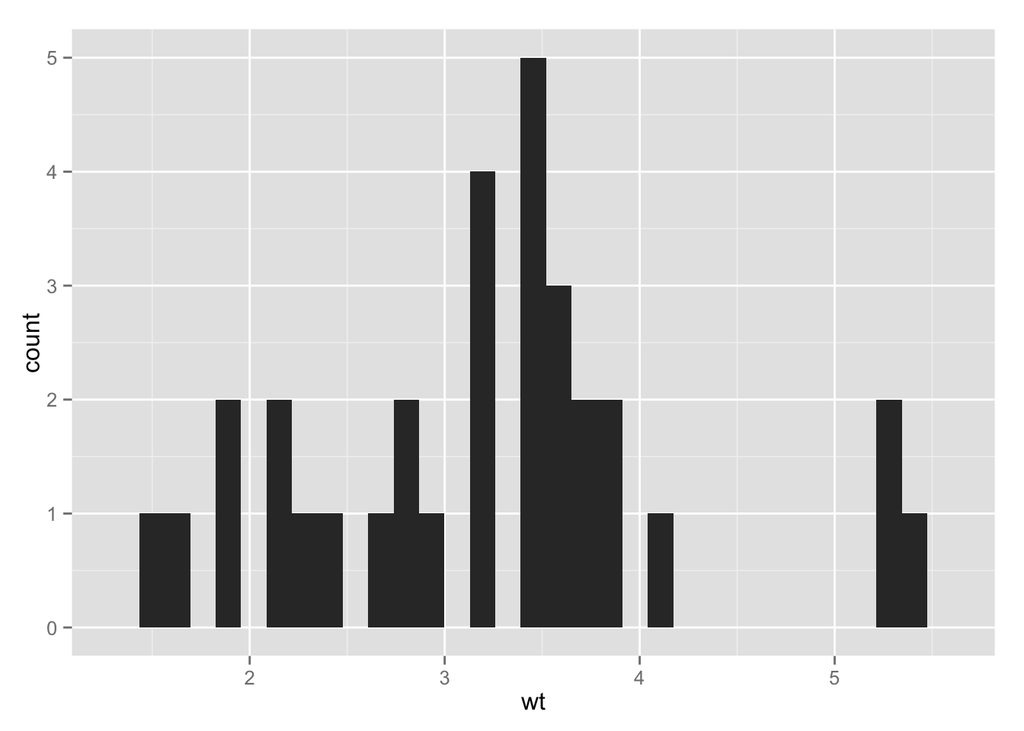

```r
#install.packages('ggplot2', dependencies = T)
library(ggplot2)
qplot(data= mtcars, x=wt)
```